# Variation of [v] in Cook Islands Māori

Quartz Colvin

Rutgers University  
quartz.colvin@rutgers.edu

Abstract

# Introduction

In this paper, we will do a statistical analysis of [v] across a sample of islands in Cook Islands Māori. It’s known that in many dialects and other varieties of Māori, this phoneme can be realized as [w] or [v]. This paper aims to take a statistical approach to this generalization.

This paper has three main questions to investigate. First, are [w]-realizing dialects associated with more voicing than [v]-realizing dialects? Second, how does intensity of [v/w] vary by island? Lastly, how does duration of the target phoneme vary by island?

# Methods

# Data

This data set contains a lot of information, so we will need to tidy it and only keep the relevant data for the analysis. The following code chunk shows how the data was tidied and what was kept from the untidy data set. I don’t show a preview of the untidy data set here because it had 17 columns and most of the columns will be taken out. In addition, it includes some metadata that I did not ask permission to share.

```r
dat <- untidy_data |>
  drop_na() |>   # remove rows that have NA values
  filter(TextGridLabel == "v") |>   # filter by 'v' for analysis
  pivot_longer(      # deal with all the f0 columns
    cols = c("f0_20.point",
             "f0_50.point",
             "f0_80.point"),
    names_to = "percent",    # names to 'percent' column
    values_to = "hz"      # values to one column called 'hz'
  ) |>
  arrange(island, Word) |>   # group by 'island', then 'word'
  select(island,      # pick which columns I want and rename some
         word = Word,
         percent, hz, duration,
         intensity = intensity_midpoint) |>
  write_csv("tidy_cim.csv")    # put tidy data in new .csv
```

In the new data set, we need to fix the names that we’ve converted to values under ‘percent’. This is shown in the following code chunk.

```r
# fixing the original column names to only be the percent
# since they are all values for f0

dat$percent[dat$percent == 'f0_20.point'] <- "20"

dat$percent[dat$percent == 'f0_50.point'] <- "50"

dat$percent[dat$percent == 'f0_80.point'] <- "80"
```

Now that we have tidied this data set, here is a preview showing what it looks like.

| island | word | percent | hz | duration | intensity |
| --- | --- | --- | --- | --- | --- |
| Atiu | ava | 20 | 128.5916 | 0.08 | 54.08202 |
| Atiu | ava | 50 | 127.0908 | 0.08 | 54.08202 |
| Atiu | ava | 80 | 127.4540 | 0.08 | 54.08202 |
| Atiu | ava | 20 | 160.6464 | 0.07 | 58.06061 |
| Atiu | ava | 50 | 157.4397 | 0.07 | 58.06061 |
| Atiu | ava | 80 | 158.2820 | 0.07 | 58.06061 |

There are many more rows than this, but if all rows were included, it would be too long of a table to show here.

# Analysis

This section readdresses the three questions. First, are [w]-realizing dialects associated with more voicing than [v]-realizing dialects? Second, how does intensity of [v/w] vary by island? Lastly, how does duration of the target phoneme vary by island?

## Voicing by island

First we use f0 values for the target phoneme to see how voicing differs across the four islands in this data set. F0 values were extracted at the 20%, 50% and 80% points of the duration of the target phoneme.

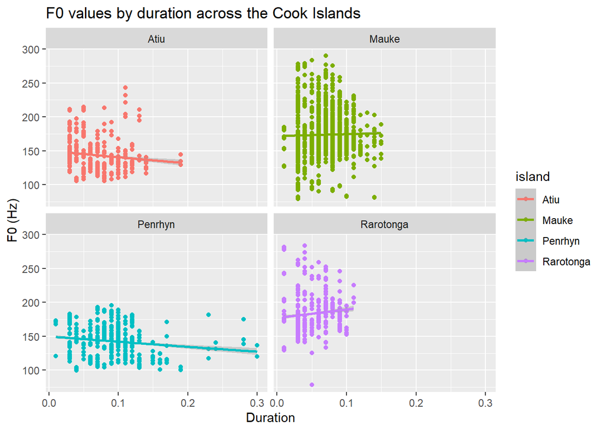

## Duration by island

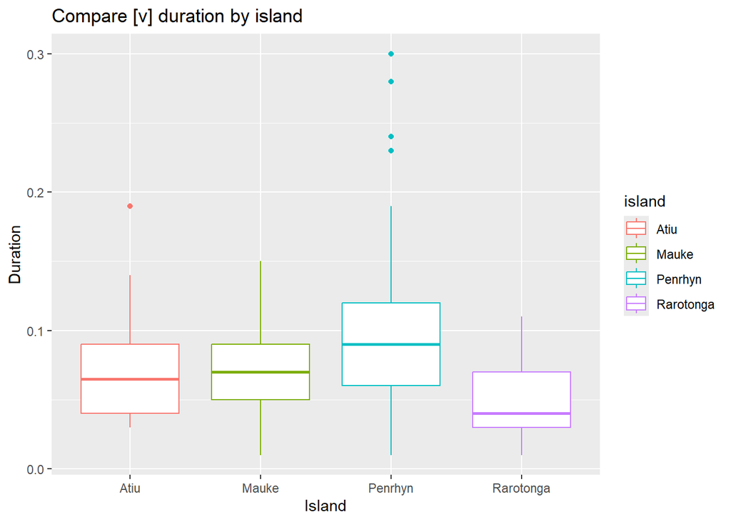

## Intensity by island

Next, in the same fashion we did to compare duration of [v] tokens, we can compare the intensity midpoints for the tokens across the islands.

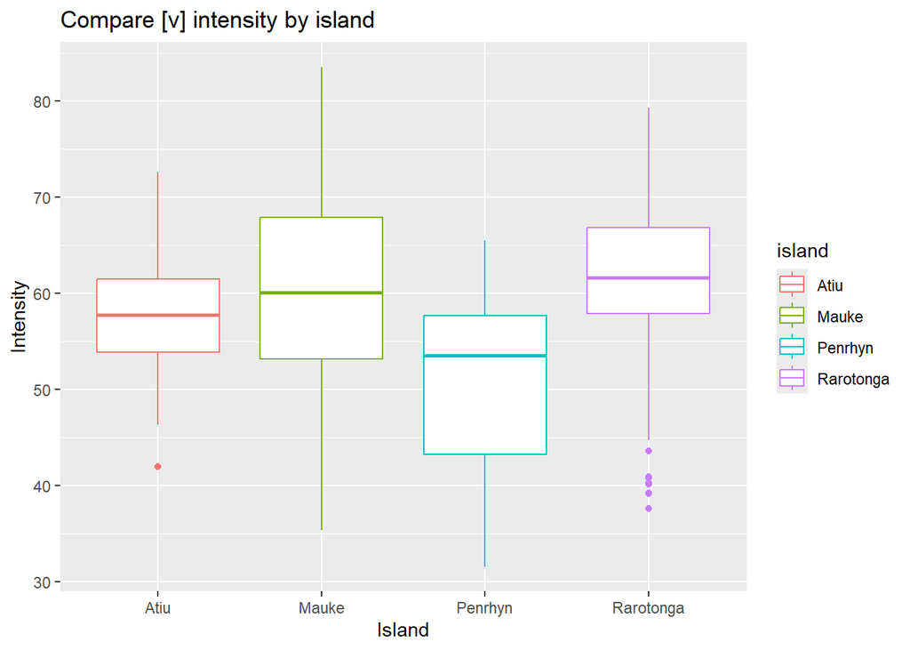

# Results

### Data analysis

# References

```r
r_refs(file = "r-references.bib")
```